# R/exams quiz

Simplify the radical:

$$\sqrt{28}$$

$$\sqrt{28}$$

Find the [prime factorization](https://en.wikipedia.org/wiki/Fundamental_theorem_of_arithmetic) of 28. You can do this with a [factor tree](https://www.khanacademy.org/math/pre-algebra/pre-algebra-factors-multiples/pre-algebra-prime-factorization-prealg/v/prime-factorization). You should find that $28=2^{2}\cdot7^{1}$.

$$\sqrt{2^{2}\cdot7^{1}}$$

[Simplify the square root](https://www.khanacademy.org/math/algebra/x2f8bb11595b61c86:rational-exponents-radicals/x2f8bb11595b61c86:simplifying-square-roots/v/simplifying-square-roots-1).

$$2 \sqrt{7}$$

Simplify the radical:

$$\sqrt{27}$$

$$\sqrt{27}$$

Find the [prime factorization](https://en.wikipedia.org/wiki/Fundamental_theorem_of_arithmetic) of 27. You can do this with a [factor tree](https://www.khanacademy.org/math/pre-algebra/pre-algebra-factors-multiples/pre-algebra-prime-factorization-prealg/v/prime-factorization). You should find that $27=3^{3}$.

$$\sqrt{3^{3}}$$

[Simplify the square root](https://www.khanacademy.org/math/algebra/x2f8bb11595b61c86:rational-exponents-radicals/x2f8bb11595b61c86:simplifying-square-roots/v/simplifying-square-roots-1).

$$3 \sqrt{3}$$

Simplify the radical:

$$\sqrt{99}$$

$$\sqrt{99}$$

Find the [prime factorization](https://en.wikipedia.org/wiki/Fundamental_theorem_of_arithmetic) of 99. You can do this with a [factor tree](https://www.khanacademy.org/math/pre-algebra/pre-algebra-factors-multiples/pre-algebra-prime-factorization-prealg/v/prime-factorization). You should find that $99=3^{2}\cdot11^{1}$.

$$\sqrt{3^{2}\cdot11^{1}}$$

[Simplify the square root](https://www.khanacademy.org/math/algebra/x2f8bb11595b61c86:rational-exponents-radicals/x2f8bb11595b61c86:simplifying-square-roots/v/simplifying-square-roots-1).

$$3 \sqrt{11}$$

Simplify the radical:

$$\sqrt{12}$$

$$\sqrt{12}$$

Find the [prime factorization](https://en.wikipedia.org/wiki/Fundamental_theorem_of_arithmetic) of 12. You can do this with a [factor tree](https://www.khanacademy.org/math/pre-algebra/pre-algebra-factors-multiples/pre-algebra-prime-factorization-prealg/v/prime-factorization). You should find that $12=2^{2}\cdot3^{1}$.

$$\sqrt{2^{2}\cdot3^{1}}$$

[Simplify the square root](https://www.khanacademy.org/math/algebra/x2f8bb11595b61c86:rational-exponents-radicals/x2f8bb11595b61c86:simplifying-square-roots/v/simplifying-square-roots-1).

$$2 \sqrt{3}$$

Simplify the radical:

$$\sqrt{8}$$

$$\sqrt{8}$$

Find the [prime factorization](https://en.wikipedia.org/wiki/Fundamental_theorem_of_arithmetic) of 8. You can do this with a [factor tree](https://www.khanacademy.org/math/pre-algebra/pre-algebra-factors-multiples/pre-algebra-prime-factorization-prealg/v/prime-factorization). You should find that $8=2^{3}$.

$$\sqrt{2^{3}}$$

[Simplify the square root](https://www.khanacademy.org/math/algebra/x2f8bb11595b61c86:rational-exponents-radicals/x2f8bb11595b61c86:simplifying-square-roots/v/simplifying-square-roots-1).

$$2 \sqrt{2}$$

Find all solutions to the equation below:

$$5 (x-{10})^2+12~=~137$$

$x=-20$$x=-19$$x=-18$$x=-17$$x=-16$$x=-15$$x=-14$$x=-13$$x=-12$$x=-11$$x=-10$$x=-9$$x=-8$$x=-7$$x=-6$$x=-5$$x=-4$$x=-3$$x=-2$$x=-1$$x=0$$x=1$$x=2$$x=3$$x=4$$x=5$$x=6$$x=7$$x=8$$x=9$$x=10$$x=11$$x=12$$x=13$$x=14$$x=15$$x=16$$x=17$$x=18$$x=19$$x=20$

$$5 (x-{10})^2+12~=~137$$

First, subtract 12 from both sides.

$$5 (x-{10})^2~=~125$$

Second, divide both sides by 5.

$$(x-{10})^2~=~25$$

Undo the squaring. Remember the plus-minus symbol!

$$x-{10}~=~\pm5$$

Add 10 to both sides.

$$x~=~10\pm5$$

So the two solutions are $x=15$ and $x=5$.

Find all solutions to the equation below:

$$\frac{(x-{7})^2-4}{3}~=~7$$

$x=-20$$x=-19$$x=-18$$x=-17$$x=-16$$x=-15$$x=-14$$x=-13$$x=-12$$x=-11$$x=-10$$x=-9$$x=-8$$x=-7$$x=-6$$x=-5$$x=-4$$x=-3$$x=-2$$x=-1$$x=0$$x=1$$x=2$$x=3$$x=4$$x=5$$x=6$$x=7$$x=8$$x=9$$x=10$$x=11$$x=12$$x=13$$x=14$$x=15$$x=16$$x=17$$x=18$$x=19$$x=20$

$$\frac{(x-{7})^2-4}{3}~=~7$$

First, multiply both sides by 3.

$$(x-{7})^2-4~=~21$$

Second, add 4 to both sides.

$$(x-{7})^2~=~25$$

Undo the squaring. Remember the plus-minus symbol!

$$x-{7}~=~\pm5$$

Add 7 to both sides.

$$x~=~7\pm5$$

So the two solutions are $x=12$ and $x=2$.

Find all solutions to the equation below:

$$4 (x+{5})^2+13~=~77$$

$x=-20$$x=-19$$x=-18$$x=-17$$x=-16$$x=-15$$x=-14$$x=-13$$x=-12$$x=-11$$x=-10$$x=-9$$x=-8$$x=-7$$x=-6$$x=-5$$x=-4$$x=-3$$x=-2$$x=-1$$x=0$$x=1$$x=2$$x=3$$x=4$$x=5$$x=6$$x=7$$x=8$$x=9$$x=10$$x=11$$x=12$$x=13$$x=14$$x=15$$x=16$$x=17$$x=18$$x=19$$x=20$

$$4 (x+{5})^2+13~=~77$$

First, subtract 13 from both sides.

$$4 (x+{5})^2~=~64$$

Second, divide both sides by 4.

$$(x+{5})^2~=~16$$

Undo the squaring. Remember the plus-minus symbol!

$$x+{5}~=~\pm4$$

Subtract 5 from both sides.

$$x~=~-5\pm4$$

So the two solutions are $x=-1$ and $x=-9$.

Find all solutions to the equation below:

$$\frac{(x+{8})^2}{12}-14~=~-11$$

$x=-20$$x=-19$$x=-18$$x=-17$$x=-16$$x=-15$$x=-14$$x=-13$$x=-12$$x=-11$$x=-10$$x=-9$$x=-8$$x=-7$$x=-6$$x=-5$$x=-4$$x=-3$$x=-2$$x=-1$$x=0$$x=1$$x=2$$x=3$$x=4$$x=5$$x=6$$x=7$$x=8$$x=9$$x=10$$x=11$$x=12$$x=13$$x=14$$x=15$$x=16$$x=17$$x=18$$x=19$$x=20$

$$\frac{(x+{8})^2}{12}-14~=~-11$$

First, add 14 to both sides.

$$\frac{(x+{8})^2}{12}~=~3$$

Second, multiply both sides by 12.

$$(x+{8})^2~=~36$$

Undo the squaring. Remember the plus-minus symbol!

$$x+{8}~=~\pm6$$

Subtract 8 from both sides.

$$x~=~-8\pm6$$

So the two solutions are $x=-2$ and $x=-14$.

Find all solutions to the equation below:

$$\frac{(x-{4})^2-19}{2}~=~3$$

$x=-20$$x=-19$$x=-18$$x=-17$$x=-16$$x=-15$$x=-14$$x=-13$$x=-12$$x=-11$$x=-10$$x=-9$$x=-8$$x=-7$$x=-6$$x=-5$$x=-4$$x=-3$$x=-2$$x=-1$$x=0$$x=1$$x=2$$x=3$$x=4$$x=5$$x=6$$x=7$$x=8$$x=9$$x=10$$x=11$$x=12$$x=13$$x=14$$x=15$$x=16$$x=17$$x=18$$x=19$$x=20$

$$\frac{(x-{4})^2-19}{2}~=~3$$

First, multiply both sides by 2.

$$(x-{4})^2-19~=~6$$

Second, add 19 to both sides.

$$(x-{4})^2~=~25$$

Undo the squaring. Remember the plus-minus symbol!

$$x-{4}~=~\pm5$$

Add 4 to both sides.

$$x~=~4\pm5$$

So the two solutions are $x=9$ and $x=-1$.

By [completing the square](https://en.wikipedia.org/wiki/Completing_the_square), find both solutions to the given equation:

$$x^2-12x~=~64$$

The given equation:

$$x^2-12x~=~64$$

In order to make the left side of the equation a [perfect square](https://www.khanacademy.org/math/math2/xe2ae2386aa2e13d6:quad-1/xe2ae2386aa2e13d6:perfect-sq/a/factoring-quadratics-perfect-squares), we can add $\left(\frac{-12}{2}\right)^2=36$ to both sides (where -12 is the linear coefficient).

$$x^2-12x+36~=~64+36$$

$$x^2-12x+36~=~100$$

We can rewrite the left side in factored form. Notice that because the left side is a perfect square, we get a squared binomial.

$$(x-6)^2~=~100$$

Because the squaring function is not one-to-one, when we "undo" it in algebra, we need to consider the possibility of multiple solutions. In this case both 10 and -10 produce 100 when squared.

$$x-6~=~\pm 10$$

And, lastly, subtract -6 from both sides of the equation.

$$x~=~6\pm10$$

$$x~=~16~~~~~~~~\text{or}~~~~~~~~x~=~-4$$

By [completing the square](https://en.wikipedia.org/wiki/Completing_the_square), find both solutions to the given equation:

$$x^2-8x~=~65$$

The given equation:

$$x^2-8x~=~65$$

In order to make the left side of the equation a [perfect square](https://www.khanacademy.org/math/math2/xe2ae2386aa2e13d6:quad-1/xe2ae2386aa2e13d6:perfect-sq/a/factoring-quadratics-perfect-squares), we can add $\left(\frac{-8}{2}\right)^2=16$ to both sides (where -8 is the linear coefficient).

$$x^2-8x+16~=~65+16$$

$$x^2-8x+16~=~81$$

We can rewrite the left side in factored form. Notice that because the left side is a perfect square, we get a squared binomial.

$$(x-4)^2~=~81$$

Because the squaring function is not one-to-one, when we "undo" it in algebra, we need to consider the possibility of multiple solutions. In this case both 9 and -9 produce 81 when squared.

$$x-4~=~\pm 9$$

And, lastly, subtract -4 from both sides of the equation.

$$x~=~4\pm9$$

$$x~=~13~~~~~~~~\text{or}~~~~~~~~x~=~-5$$

By [completing the square](https://en.wikipedia.org/wiki/Completing_the_square), find both solutions to the given equation:

$$x^2-8x~=~0$$

The given equation:

$$x^2-8x~=~0$$

In order to make the left side of the equation a [perfect square](https://www.khanacademy.org/math/math2/xe2ae2386aa2e13d6:quad-1/xe2ae2386aa2e13d6:perfect-sq/a/factoring-quadratics-perfect-squares), we can add $\left(\frac{-8}{2}\right)^2=16$ to both sides (where -8 is the linear coefficient).

$$x^2-8x+16~=~16$$

$$x^2-8x+16~=~16$$

We can rewrite the left side in factored form. Notice that because the left side is a perfect square, we get a squared binomial.

$$(x-4)^2~=~16$$

Because the squaring function is not one-to-one, when we "undo" it in algebra, we need to consider the possibility of multiple solutions. In this case both 4 and -4 produce 16 when squared.

$$x-4~=~\pm 4$$

And, lastly, subtract -4 from both sides of the equation.

$$x~=~4\pm4$$

$$x~=~8~~~~~~~~\text{or}~~~~~~~~x~=~0$$

By [completing the square](https://en.wikipedia.org/wiki/Completing_the_square), find both solutions to the given equation:

$$x^2-10x~=~-9$$

The given equation:

$$x^2-10x~=~-9$$

In order to make the left side of the equation a [perfect square](https://www.khanacademy.org/math/math2/xe2ae2386aa2e13d6:quad-1/xe2ae2386aa2e13d6:perfect-sq/a/factoring-quadratics-perfect-squares), we can add $\left(\frac{-10}{2}\right)^2=25$ to both sides (where -10 is the linear coefficient).

$$x^2-10x+25~=~-9+25$$

$$x^2-10x+25~=~16$$

We can rewrite the left side in factored form. Notice that because the left side is a perfect square, we get a squared binomial.

$$(x-5)^2~=~16$$

Because the squaring function is not one-to-one, when we "undo" it in algebra, we need to consider the possibility of multiple solutions. In this case both 4 and -4 produce 16 when squared.

$$x-5~=~\pm 4$$

And, lastly, subtract -5 from both sides of the equation.

$$x~=~5\pm4$$

$$x~=~9~~~~~~~~\text{or}~~~~~~~~x~=~1$$

By [completing the square](https://en.wikipedia.org/wiki/Completing_the_square), find both solutions to the given equation:

$$x^2+10x~=~-16$$

The given equation:

$$x^2+10x~=~-16$$

In order to make the left side of the equation a [perfect square](https://www.khanacademy.org/math/math2/xe2ae2386aa2e13d6:quad-1/xe2ae2386aa2e13d6:perfect-sq/a/factoring-quadratics-perfect-squares), we can add $\left(\frac{10}{2}\right)^2=25$ to both sides (where 10 is the linear coefficient).

$$x^2+10x+25~=~-16+25$$

$$x^2+10x+25~=~9$$

We can rewrite the left side in factored form. Notice that because the left side is a perfect square, we get a squared binomial.

$$(x+5)^2~=~9$$

Because the squaring function is not one-to-one, when we "undo" it in algebra, we need to consider the possibility of multiple solutions. In this case both 3 and -3 produce 9 when squared.

$$x+5~=~\pm 3$$

And, lastly, subtract 5 from both sides of the equation.

$$x~=~-5\pm3$$

$$x~=~-2~~~~~~~~\text{or}~~~~~~~~x~=~-8$$

Quadratic polynomial $p$ is defined below in standard form.
$$p(x)~=~{2}x^{2}-{8}x+{5}$$

By [completing the square](https://en.wikipedia.org/wiki/Completing_the_square), you can rewrite the quadratic polynomial in vertex form:

$$p(x) = a(x-h)^2+k$$

where $(h,k)$ is the vertex of the parabola. Determine the coordinates of the vertex of quadratic polynomial $p$.

- $h=$
- $k=$

We are given $p(x)~=~{2}x^{2}-{8}x+{5}$. From the first two terms, factor out 2.

$$p(x)~=~2\left(x^{2}-{4}x\right)+{5}$$

Determine the constant needed to complete the square (of the expression inside parentheses) by dividing the linear coefficient by 2 and then squaring the result. $\left(\frac{-4}{2}\right)^2 ~=~ \left(-2\right)^2 ~=~ 4$. Add and subtract this amount inside the parentheses.

$$p(x)~=~2\left(x^{2}-{4}x+{4}-{4}\right)+{5}$$

Notice the first three terms inside the parentheses are a perfect square. Rewrite them in factored form.

$$p(x)~=~2\left(\left(x-{2}\right)^2-4\right)+{5}$$

Distribute the 2.

$$p(x)~=~2\left(x-{2}\right)^2-8+{5}$$

Combine the constants.

$$p(x)~=~2\left(x-{2}\right)^2
-{3}$$

And so:

$$h = 2$$
$$k = -3$$

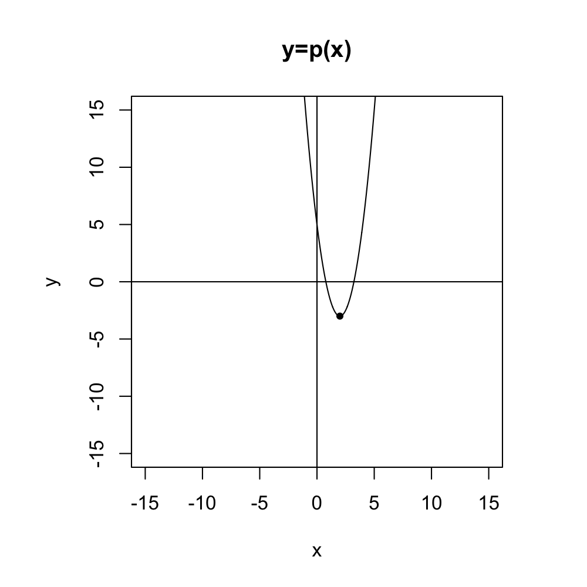

Quadratic polynomial $p$ is defined below in standard form.
$$p(x)~=~{5}x^{2}+{90}x+{411}$$

By [completing the square](https://en.wikipedia.org/wiki/Completing_the_square), you can rewrite the quadratic polynomial in vertex form:

$$p(x) = a(x-h)^2+k$$

where $(h,k)$ is the vertex of the parabola. Determine the coordinates of the vertex of quadratic polynomial $p$.

- $h=$
- $k=$

We are given $p(x)~=~{5}x^{2}+{90}x+{411}$. From the first two terms, factor out 5.

$$p(x)~=~5\left(x^{2}+{18}x\right)+{411}$$

Determine the constant needed to complete the square (of the expression inside parentheses) by dividing the linear coefficient by 2 and then squaring the result. $\left(\frac{18}{2}\right)^2 ~=~ \left(9\right)^2 ~=~ 81$. Add and subtract this amount inside the parentheses.

$$p(x)~=~5\left(x^{2}+{18}x+{81}-{81}\right)+{411}$$

Notice the first three terms inside the parentheses are a perfect square. Rewrite them in factored form.

$$p(x)~=~5\left(\left(x+{9}\right)^2-81\right)+{411}$$

Distribute the 5.

$$p(x)~=~5\left(x+{9}\right)^2-405+{411}$$

Combine the constants.

$$p(x)~=~5\left(x+{9}\right)^2
+{6}$$

And so:

$$h = -9$$
$$k = 6$$

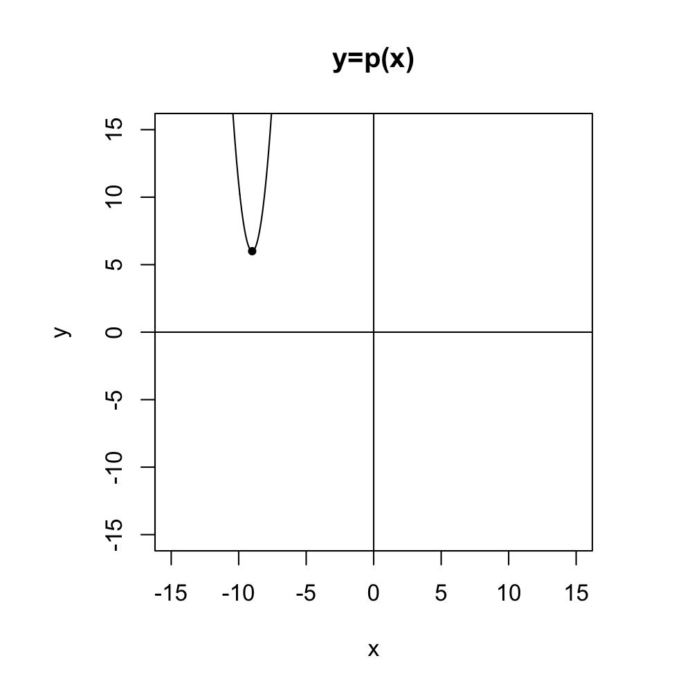

Quadratic polynomial $p$ is defined below in standard form.
$$p(x)~=~{4}x^{2}+{64}x+{249}$$

By [completing the square](https://en.wikipedia.org/wiki/Completing_the_square), you can rewrite the quadratic polynomial in vertex form:

$$p(x) = a(x-h)^2+k$$

where $(h,k)$ is the vertex of the parabola. Determine the coordinates of the vertex of quadratic polynomial $p$.

- $h=$
- $k=$

We are given $p(x)~=~{4}x^{2}+{64}x+{249}$. From the first two terms, factor out 4.

$$p(x)~=~4\left(x^{2}+{16}x\right)+{249}$$

Determine the constant needed to complete the square (of the expression inside parentheses) by dividing the linear coefficient by 2 and then squaring the result. $\left(\frac{16}{2}\right)^2 ~=~ \left(8\right)^2 ~=~ 64$. Add and subtract this amount inside the parentheses.

$$p(x)~=~4\left(x^{2}+{16}x+{64}-{64}\right)+{249}$$

Notice the first three terms inside the parentheses are a perfect square. Rewrite them in factored form.

$$p(x)~=~4\left(\left(x+{8}\right)^2-64\right)+{249}$$

Distribute the 4.

$$p(x)~=~4\left(x+{8}\right)^2-256+{249}$$

Combine the constants.

$$p(x)~=~4\left(x+{8}\right)^2
-{7}$$

And so:

$$h = -8$$
$$k = -7$$

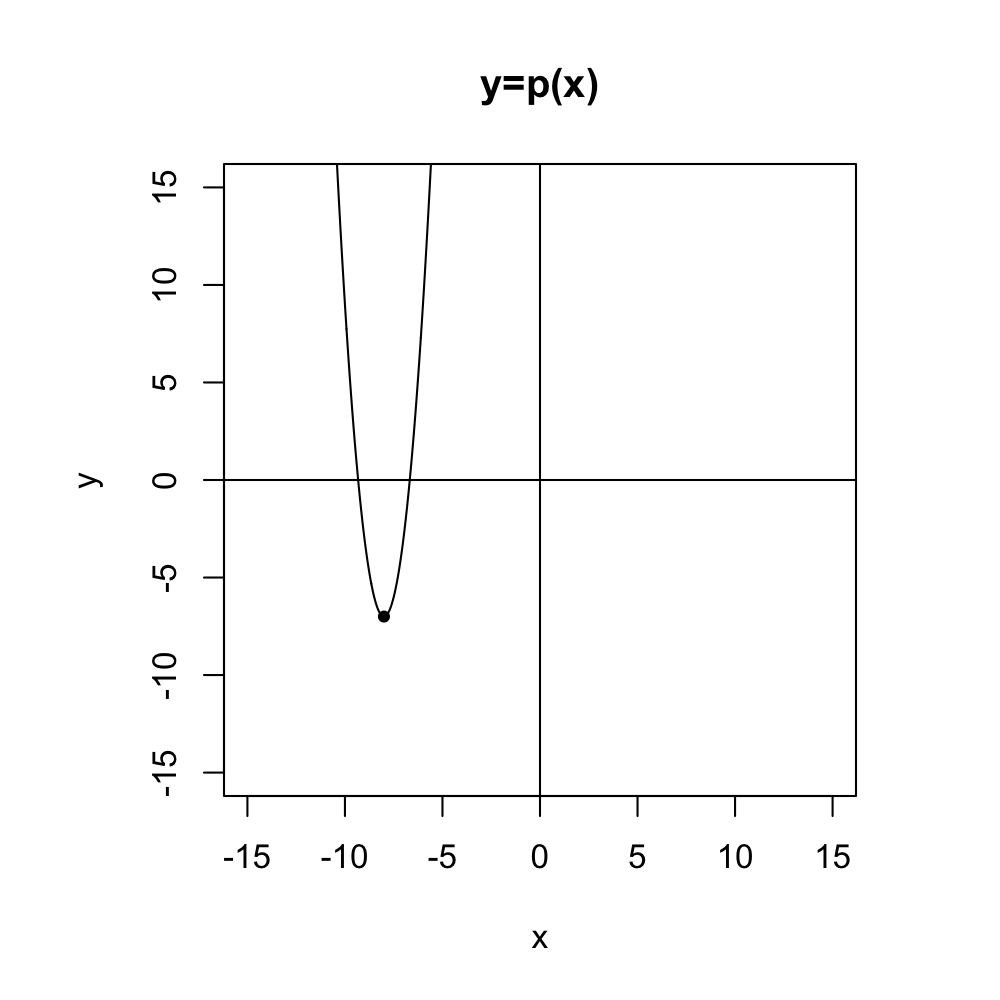

Quadratic polynomial $p$ is defined below in standard form.
$$p(x)~=~{3}x^{2}-{12}x+{20}$$

By [completing the square](https://en.wikipedia.org/wiki/Completing_the_square), you can rewrite the quadratic polynomial in vertex form:

$$p(x) = a(x-h)^2+k$$

where $(h,k)$ is the vertex of the parabola. Determine the coordinates of the vertex of quadratic polynomial $p$.

- $h=$
- $k=$

We are given $p(x)~=~{3}x^{2}-{12}x+{20}$. From the first two terms, factor out 3.

$$p(x)~=~3\left(x^{2}-{4}x\right)+{20}$$

Determine the constant needed to complete the square (of the expression inside parentheses) by dividing the linear coefficient by 2 and then squaring the result. $\left(\frac{-4}{2}\right)^2 ~=~ \left(-2\right)^2 ~=~ 4$. Add and subtract this amount inside the parentheses.

$$p(x)~=~3\left(x^{2}-{4}x+{4}-{4}\right)+{20}$$

Notice the first three terms inside the parentheses are a perfect square. Rewrite them in factored form.

$$p(x)~=~3\left(\left(x-{2}\right)^2-4\right)+{20}$$

Distribute the 3.

$$p(x)~=~3\left(x-{2}\right)^2-12+{20}$$

Combine the constants.

$$p(x)~=~3\left(x-{2}\right)^2
+{8}$$

And so:

$$h = 2$$
$$k = 8$$

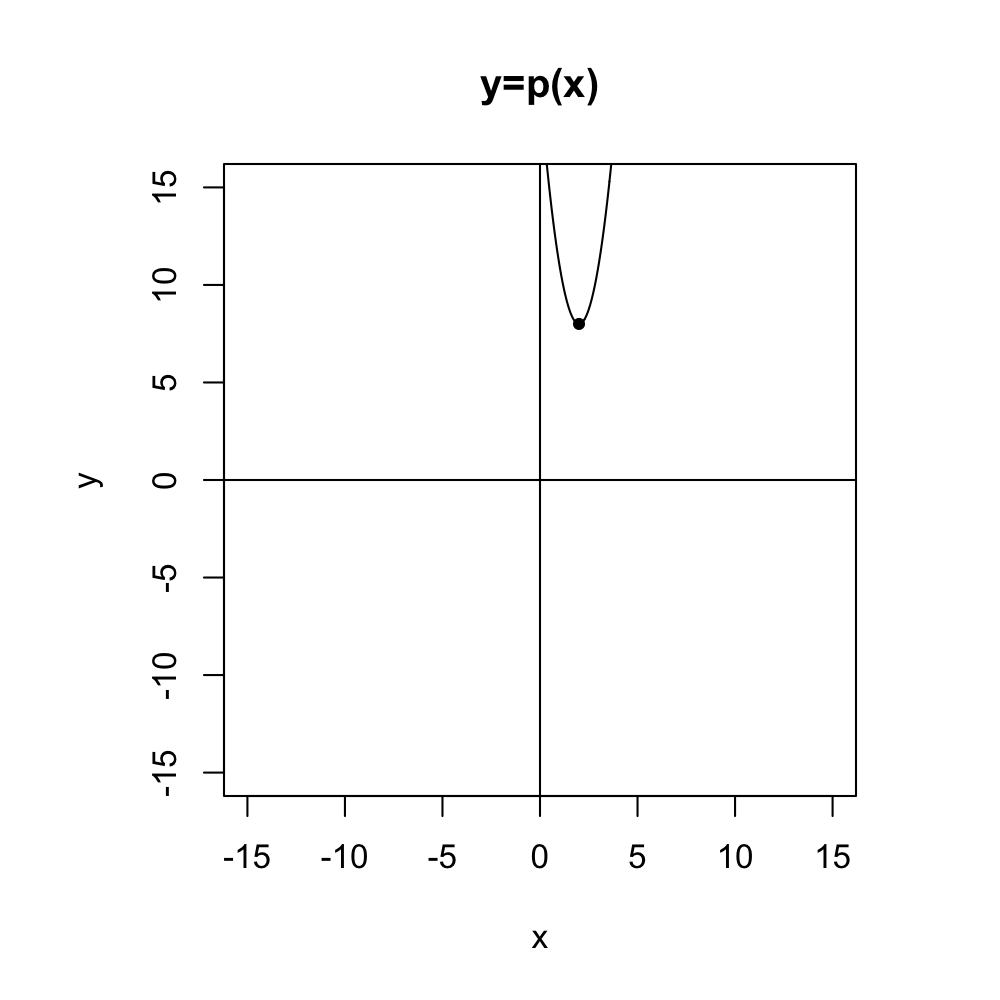

Quadratic polynomial $p$ is defined below in standard form.
$$p(x)~=~{5}x^{2}-{30}x+{51}$$

By [completing the square](https://en.wikipedia.org/wiki/Completing_the_square), you can rewrite the quadratic polynomial in vertex form:

$$p(x) = a(x-h)^2+k$$

where $(h,k)$ is the vertex of the parabola. Determine the coordinates of the vertex of quadratic polynomial $p$.

- $h=$
- $k=$

We are given $p(x)~=~{5}x^{2}-{30}x+{51}$. From the first two terms, factor out 5.

$$p(x)~=~5\left(x^{2}-{6}x\right)+{51}$$

Determine the constant needed to complete the square (of the expression inside parentheses) by dividing the linear coefficient by 2 and then squaring the result. $\left(\frac{-6}{2}\right)^2 ~=~ \left(-3\right)^2 ~=~ 9$. Add and subtract this amount inside the parentheses.

$$p(x)~=~5\left(x^{2}-{6}x+{9}-{9}\right)+{51}$$

Notice the first three terms inside the parentheses are a perfect square. Rewrite them in factored form.

$$p(x)~=~5\left(\left(x-{3}\right)^2-9\right)+{51}$$

Distribute the 5.

$$p(x)~=~5\left(x-{3}\right)^2-45+{51}$$

Combine the constants.

$$p(x)~=~5\left(x-{3}\right)^2
+{6}$$

And so:

$$h = 3$$
$$k = 6$$

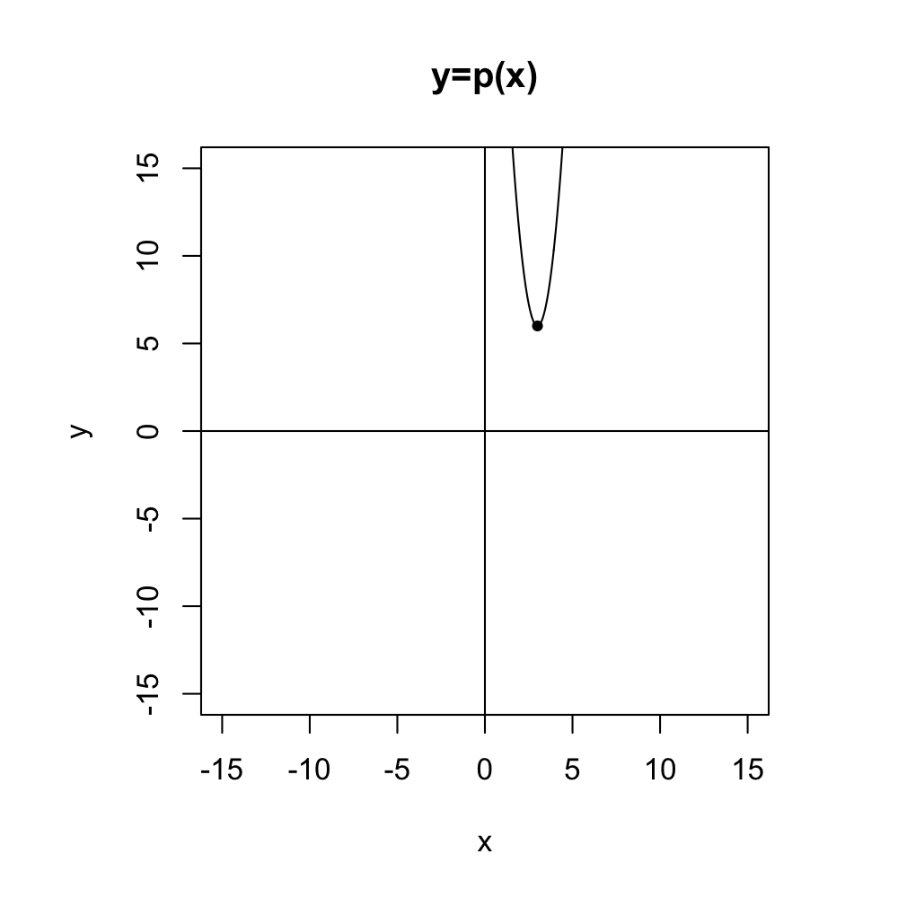